# AllLife Credit Card Customer Segmentation by Warren Camp

# 1. Perform univariate analysis on the data to better understand the variables at your disposal and to get an idea about the no of clusters. Perform EDA, create visualizations to explore data. (10 marks)

```python
# Check out the data for any issues
print(df.info())
print(df.shape)
df_Attr = df.iloc[:,1:]
print(df_Attr.head())
```

```
<class 'pandas.core.frame.DataFrame'>
RangeIndex: 660 entries, 0 to 659
Data columns (total 7 columns):
 #   Column               Non-Null Count  Dtype
---  ------               --------------  -----
 0   Sl_No                660 non-null    int64
 1   Customer Key         660 non-null    int64
 2   Avg_Credit_Limit     660 non-null    int64
 3   Total_Credit_Cards   660 non-null    int64
 4   Total_visits_bank    660 non-null    int64
 5   Total_visits_online  660 non-null    int64
 6   Total_calls_made     660 non-null    int64
dtypes: int64(7)
memory usage: 36.2 KB
None
(660, 7)
   Customer Key  Avg_Credit_Limit  Total_Credit_Cards  Total_visits_bank  \
0         87073            100000                   2                  1
1         38414             50000                   3                  0
2         17341             50000                   7                  1
3         40496             30000                   5                  1
4         47437            100000                   6                  0

   Total_visits_online  Total_calls_made
0                    1                 0
1                   10                 9
2                    3                 4
3                    1                 4
4                   12                 3
```

```python
print(df.describe())
```

```
            Sl_No  Customer Key  Avg_Credit_Limit  Total_Credit_Cards  \
count  660.000000    660.000000        660.000000          660.000000
mean   330.500000  55141.443939      34574.242424            4.706061
std    190.669872  25627.772200      37625.487804            2.167835
min      1.000000  11265.000000       3000.000000            1.000000
25%    165.750000  33825.250000      10000.000000            3.000000
50%    330.500000  53874.500000      18000.000000            5.000000
75%    495.250000  77202.500000      48000.000000            6.000000
max    660.000000  99843.000000     200000.000000           10.000000

       Total_visits_bank  Total_visits_online  Total_calls_made
count         660.000000           660.000000        660.000000
mean            2.403030             2.606061          3.583333
std             1.631813             2.935724          2.865317
min             0.000000             0.000000          0.000000
25%             1.000000             1.000000          1.000000
50%             2.000000             2.000000          3.000000
75%             4.000000             4.000000          5.000000
max             5.000000            15.000000         10.000000
```

```python
# There are no negative values.
```

```python
# Check for Null or missing values
print(df.isnull().sum())
```

```
Sl_No                  0
Customer Key           0
Avg_Credit_Limit       0
Total_Credit_Cards     0
Total_visits_bank      0
Total_visits_online    0
Total_calls_made       0
dtype: int64
```

```python
# Thdere are no missing or null values
```

```python
# check for duplicates records
print(df.duplicated(keep='first').sum())
if df.duplicated(keep='first').sum() > 0:
    df = df.drop_duplicates()
print(df.duplicated(keep='first').sum())
```

```
0
0
```

# There are no duplicate records

```python
# Drop Customer Key and SI No because they are not related to this problem or solution
df.drop(columns=['Customer Key', 'Sl_No'], axis = 1, inplace=True)
df.columns
```

```
Index(['Avg_Credit_Limit', 'Total_Credit_Cards', 'Total_visits_bank',
       'Total_visits_online', 'Total_calls_made'],
      dtype='object')
```

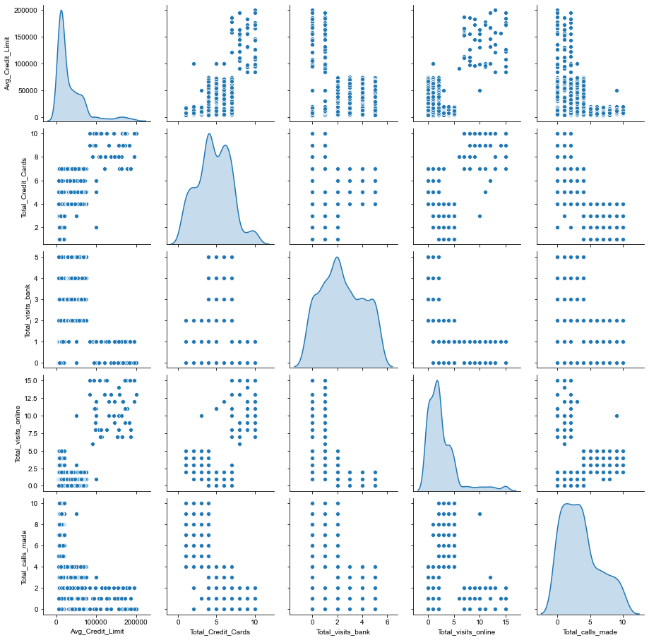

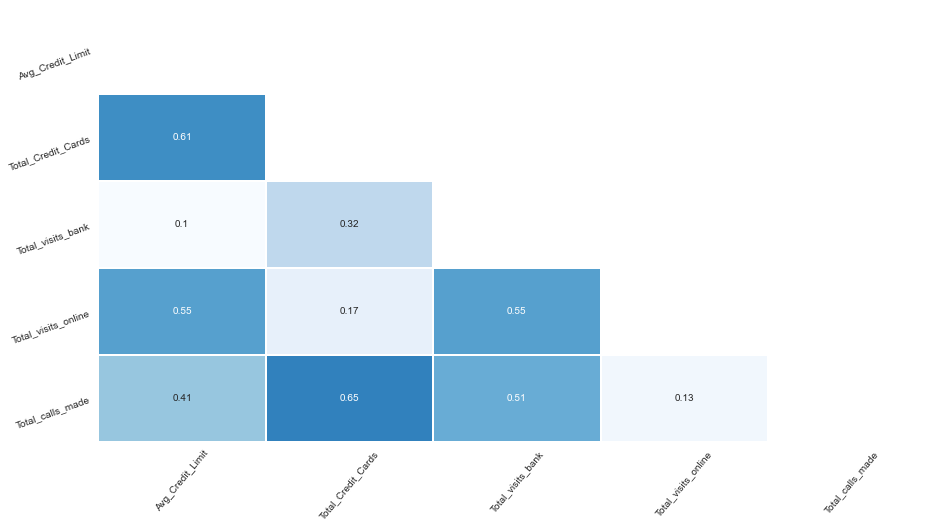

```python
sns.pairplot(df, diag_kind = 'kde')
np.tril(df.corr(), k = -1)
corr = abs(df.corr()) # correlation matrix
lower_triangle = np.tril(corr, k = -1)  # select only the lower triangle of the correlation matrix
mask = lower_triangle == 0  # to mask the upper triangle in the following heatmap

plt.figure(figsize = (15,8))  # setting the figure size
sns.set_style(style = 'white')  # Setting it to white so that we do not see the grid lines
sns.heatmap(lower_triangle, center=0.5, cmap= 'Blues', annot= True, xticklabels = corr.index, yticklabels = corr.columns,
            cbar= False, linewidths= 1, mask = mask)   # Da Heatmap
plt.xticks(rotation = 50)   # Aesthetic purposes
plt.yticks(rotation = 20)   # Aesthetic purposes
plt.show()
```

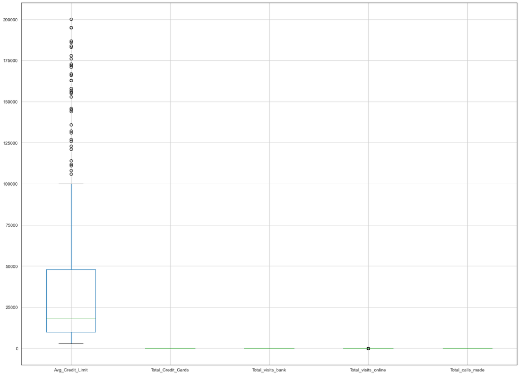

```python
df.boxplot(figsize=(20, 15))
```

```python
# outliers exist for Avg Credit Limit and Total visits online
print(df.nunique())
```

```
Avg_Credit_Limit       110
Total_Credit_Cards      10
Total_visits_bank        6
Total_visits_online     16
Total_calls_made        11
dtype: int64
```

```python
#  Avg_Credit_Limit has larget number of outliers whick we will reduce.
print(df['Avg_Credit_Limit'].value_counts())
df['Avg_Credit_Limit'] = np.where(df['Avg_Credit_Limit'] > 105000, 105000, df['Avg_Credit_Limit'])
print(df['Avg_Credit_Limit'].value_counts())
```

```
8000      35
6000      31
9000      28
13000     28
10000     26
          ..
25000      1
153000     1
111000     1
112000     1
106000     1
Name: Avg_Credit_Limit, Length: 110, dtype: int64
105000    39
8000      35
6000      31
9000      28
13000     28
          ..
95000      1
94000      1
91000      1
3000       1
43000      1
Name: Avg_Credit_Limit, Length: 77, dtype: int64
```

```python
#  Total_visits_online has small number of outliers whick we will reduce.
print(df['Total_visits_online'].value_counts())
df['Total_visits_online'] = np.where(df['Total_visits_online'] > 8, 8, df['Total_visits_online'])
print(df['Total_visits_online'].value_counts())
```

```
2     189
0     144
1     109
4      69
5      54
3      44
15     10
7       7
12      6
10      6
8       6
13      5
11      5
9       4
14      1
6       1
Name: Total_visits_online, dtype: int64
2    189
0    144
1    109
4     69
5     54
3     44
8     43
7      7
6      1
Name: Total_visits_online, dtype: int64
```

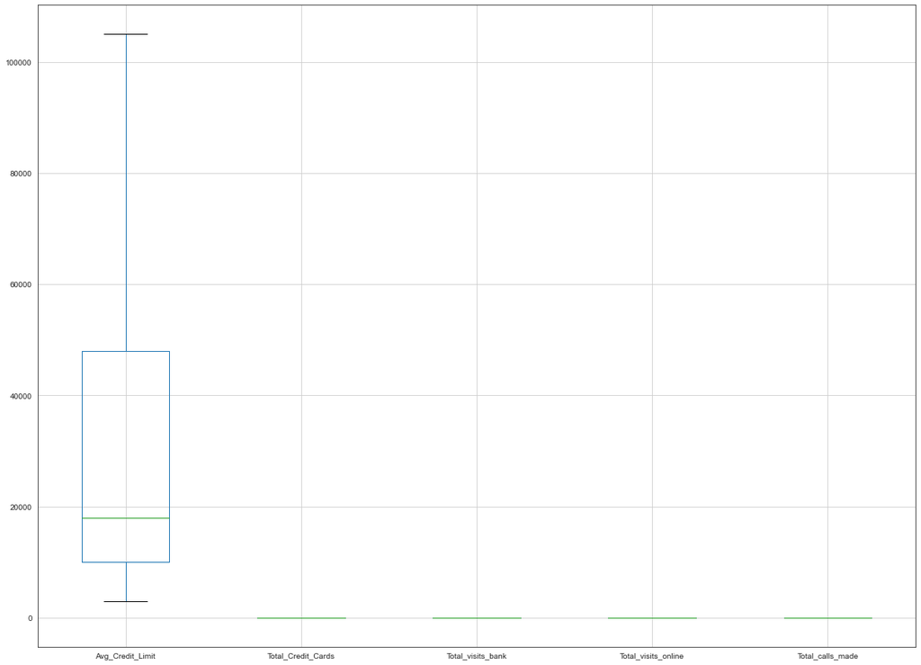

```python
# All outliers have been filtered.
df.boxplot(figsize=(20, 15))
```

```python
df_filtered = df
df_filtered
```

|  | Avg_Credit_Limit | Total_Credit_Cards | Total_visits_bank | Total_visits_online | Total_calls_made |
| --- | --- | --- | --- | --- | --- |
| 0 | 100000 | 2 | 1 | 1 | 0 |
| 1 | 50000 | 3 | 0 | 8 | 9 |
| 2 | 50000 | 7 | 1 | 3 | 4 |
| 3 | 30000 | 5 | 1 | 1 | 4 |
| 4 | 100000 | 6 | 0 | 8 | 3 |
| ... | ... | ... | ... | ... | ... |
| 655 | 99000 | 10 | 1 | 8 | 0 |
| 656 | 84000 | 10 | 1 | 8 | 2 |
| 657 | 105000 | 8 | 1 | 8 | 1 |
| 658 | 105000 | 10 | 1 | 8 | 0 |
| 659 | 105000 | 9 | 0 | 8 | 2 |

660 rows × 5 columns

# 2. Properly comment on the codes, provide explanations of the steps taken in the notebook and conclude your insights from the graphs. (5 marks)

# ---------------------------------------------------------------------------------------------------

# Comments: There are 660 observations and 7 features There is no missing or duplicate observations. Some skewness in the data: Avg_Credit_Limit and Total_visits_online. Some data dependencies, for example in: Total_Credit_Cards and Sl_No and Total_calls_made and Sl_No.

# Customer Key and Sl_No were dropped because they are not related to the problem.

# Avg_Credit_Limit and Total_visits_online perform outlier filtering to reduce the number of outliers.

# Based on a review of the kde plots, 4 (Total_Credit_Cards) or 5 clusters (Total_visits_bank).

# ----------------------------------------------------------------------------------------------------

# 3. Execute K-means clustering use elbow plot and analyse clusters using boxplot (10 marks)

```python
##Scale the data
df_z = df.apply(zscore)
df_z.head()
```

|  | Avg_Credit_Limit | Total_Credit_Cards | Total_visits_bank | Total_visits_online | Total_calls_made |
| --- | --- | --- | --- | --- | --- |
| 0 | 2.398942 | -1.249225 | -0.860451 | -0.627980 | -1.251537 |
| 1 | 0.643619 | -0.787585 | -1.473731 | 2.581387 | 1.891859 |
| 2 | 0.643619 | 1.058973 | -0.860451 | 0.288982 | 0.145528 |
| 3 | -0.058511 | 0.135694 | -0.860451 | -0.627980 | 0.145528 |
| 4 | 2.398942 | 0.597334 | -1.473731 | 2.581387 | -0.203739 |

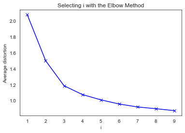

```python
#Finding optimal no. of clusters
clusters=range(1,10)
meanDistortions=[]

for i in clusters:
    model=KMeans(n_clusters=i)
    model.fit(df_z)
    prediction=model.predict(df_z)
    meanDistortions.append(sum(np.min(cdist(df_z, model.cluster_centers_, 'euclidean'), axis=1)) / df_z.shape[0])

plt.plot(clusters, meanDistortions, 'bx-')
plt.xlabel('i')
plt.ylabel('Average distortion')
plt.title('Selecting i with the Elbow Method')
```

```python
# Based on elbow method the optimal number of clusters are 3
```

```python
#Set the value of k=3
kmeans = KMeans(n_clusters=3, n_init = 15, random_state=13)
```

```python
kmeans.fit(df_z)
label = kmeans.predict(df_z)
df_ScaledKMeans = df_z  # Retain the values for the  Sihouette Score
label_KMeans = label    # Retain the values for the  Sihouette Score
```

```python
centroids = kmeans.cluster_centers_
```

```python
centroids
```

```
array([[-0.68431485, -1.05962278, -0.9015185 ,  0.53869043,  1.14810882],
       [ 0.07427533,  0.37368962,  0.6663945 , -0.63629453, -0.55300488],
       [ 2.49232493,  1.86222621, -1.10576269,  2.49886068, -0.87432983]])
```

```python
#Calculate the centroids for the columns to profile
centroid_df = pd.DataFrame(centroids, columns = list(df_z) )
```

```python
print(centroid_df)
```

```
   Avg_Credit_Limit  Total_Credit_Cards  Total_visits_bank  \
0         -0.684315           -1.059623          -0.901518
1          0.074275            0.373690           0.666395
2          2.492325            1.862226          -1.105763

   Total_visits_online  Total_calls_made
0             0.538690          1.148109
1            -0.636295         -0.553005
2             2.498861         -0.874330
```

```python
# Cluster 2 has the lowest values (-0.636295) and cluster 3 has the highest values (2.498861)
print('Minimum values: \n', centroid_df.min().sort_values())

print('\n Maximum values: \n', centroid_df.max().sort_values())
```

```
Minimum values:
 Total_visits_bank     -1.105763
Total_Credit_Cards    -1.059623
Total_calls_made      -0.874330
Avg_Credit_Limit      -0.684315
Total_visits_online   -0.636295
dtype: float64

 Maximum values:
 Total_visits_bank      0.666395
Total_calls_made       1.148109
Total_Credit_Cards     1.862226
Avg_Credit_Limit       2.492325
Total_visits_online    2.498861
dtype: float64
```

```python
## creating a new dataframe only for labels and converting it into categorical variable
df_labels = pd.DataFrame(kmeans.labels_ , columns = list(['labels']))

df_labels['labels'] = df_labels['labels'].astype('category')
```

```python
# Joining the label dataframe with the data frame.
df_labeled = df.join(df_labels)
```

```python
df_analysis = (df_labeled.groupby(['labels'] , axis=0)).count()  # the groupby creates a grouped dataframe that needs
# to be converted back to dataframe.
df_analysis
```

| labels | Avg_Credit_Limit | Total_Credit_Cards | Total_visits_bank | Total_visits_online | Total_calls_made |
| --- | --- | --- | --- | --- | --- |
| 0 | 224 | 224 | 224 | 224 | 224 |
| 1 | 386 | 386 | 386 | 386 | 386 |
| 2 | 50 | 50 | 50 | 50 | 50 |

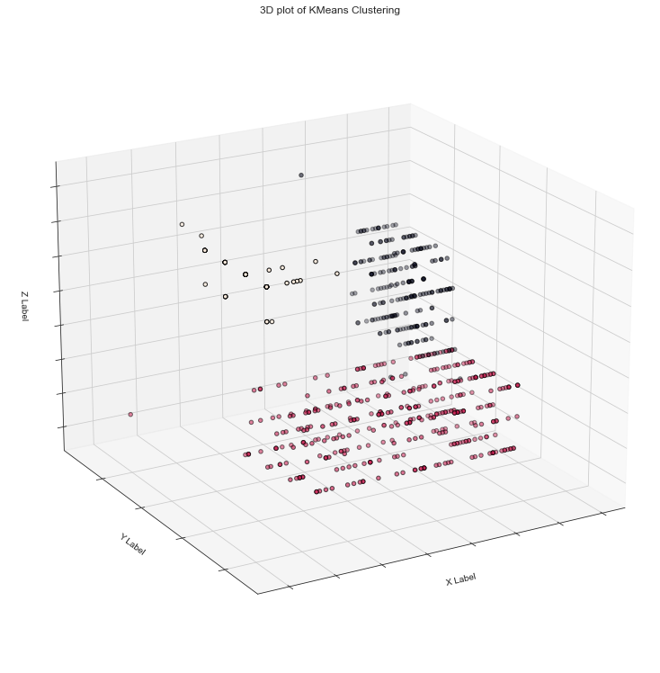

```python
## 3D plots of clusters
fig = plt.figure(figsize=(12, 10))
ax = Axes3D(fig, rect=[0, 0, .95, 1], elev=20, azim=60)
kmeans.fit(df_z)
labels = kmeans.labels_
ax.scatter(df_z.iloc[:, 0], df_z.iloc[:, 1], df_z.iloc[:, 3],c=labels.astype(np.float), edgecolor='k')
ax.w_xaxis.set_ticklabels([])
ax.w_yaxis.set_ticklabels([])
ax.w_zaxis.set_ticklabels([])
ax.set_xlabel('X Label')
ax.set_ylabel('Y Label')
ax.set_zlabel('Z Label')
ax.set_title('3D plot of KMeans Clustering')
```

```python
# 3 clusters are clearly shown in the above 3D plot
```

```python
# Collect the mean featue for each Cluster
algo = []
cv_Credit_Limit = []
cv_Credit_Cards = []
cv_visits_bank = []
cv_visits_online = []
cv_calls_made = []
cluster_count = []
df_Grp0 =pd.DataFrame()
df_Grp0 = df_labeled[df_labeled['labels']== 0]
print(df_Grp0.median())
algo.append('Cluster1')
cv_Credit_Limit.append(df_Grp0.mean()[0])
cv_Credit_Cards.append(df_Grp0. mean()[1])
cv_visits_bank.append(df_Grp0.mean()[2])
cv_visits_online.append(df_Grp0.mean()[3])
cv_calls_made.append(df_Grp0.mean()[4])
cluster_count.append(df_Grp0.shape[0])
```

```
Avg_Credit_Limit       12000.0
Total_Credit_Cards         2.0
Total_visits_bank          1.0
Total_visits_online        4.0
Total_calls_made           7.0
dtype: float64
```

```python
df_Grp1 = pd.DataFrame()
df_Grp1 = df_labeled[df_labeled['labels']== 1]
print(df_Grp1.median())
algo.append('Cluster2')
cv_Credit_Limit.append(df_Grp1.mean()[0])
cv_Credit_Cards.append(df_Grp1.mean()[1])
cv_visits_bank.append(df_Grp1.mean()[2])
cv_visits_online.append(df_Grp1.mean()[3])
cv_calls_made.append(df_Grp1.mean()[4])
cluster_count.append(df_Grp1.shape[0])
```

```
Avg_Credit_Limit       31000.0
Total_Credit_Cards         6.0
Total_visits_bank          3.0
Total_visits_online        1.0
Total_calls_made           2.0
dtype: float64
```

```python
df_Grp2 = pd.DataFrame()
df_Grp2 = df_labeled[df_labeled['labels']== 2]
print(df_Grp2.median())
algo.append('Cluster3')
cv_Credit_Limit.append(df_Grp2.mean()[0])
cv_Credit_Cards.append(df_Grp2.mean()[1])
cv_visits_bank.append(df_Grp2.mean()[2])
cv_visits_online.append(df_Grp2.mean()[3])
cv_calls_made.append(df_Grp2.mean()[4])
cluster_count.append(df_Grp2.shape[0])
```

```
Avg_Credit_Limit       105000.0
Total_Credit_Cards          9.0
Total_visits_bank           1.0
Total_visits_online         8.0
Total_calls_made            1.0
dtype: float64
```

```
array([[<AxesSubplot:title={'center':'Avg_Credit_Limit'}, xlabel='labels'>,
        <AxesSubplot:>, <AxesSubplot:>, <AxesSubplot:>],
       [<AxesSubplot:>, <AxesSubplot:>, <AxesSubplot:>, <AxesSubplot:>]],
      dtype=object)
```

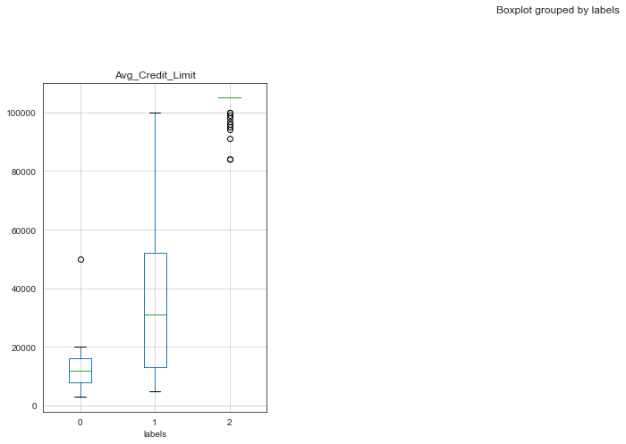

```python
df_labeled.boxplot(column=['Avg_Credit_Limit'], by = 'labels',  layout=(2,4), figsize=(20, 15))
```

```
array([[<AxesSubplot:title={'center':'Total_Credit_Cards'}, xlabel='labels'>,
        <AxesSubplot:>, <AxesSubplot:>, <AxesSubplot:>],
       [<AxesSubplot:>, <AxesSubplot:>, <AxesSubplot:>, <AxesSubplot:>]],
      dtype=object)
```

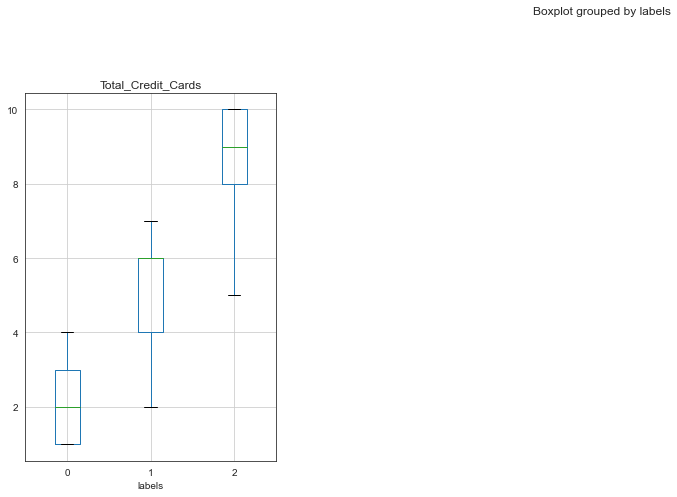

```python
df_labeled.boxplot(column=['Total_Credit_Cards', ], by = 'labels',  layout=(2,4), figsize=(20, 15))
```

```
array([[<AxesSubplot:title={'center':'Total_visits_bank'}, xlabel='labels'>,
        <AxesSubplot:>, <AxesSubplot:>, <AxesSubplot:>],
       [<AxesSubplot:>, <AxesSubplot:>, <AxesSubplot:>, <AxesSubplot:>]],
      dtype=object)
```

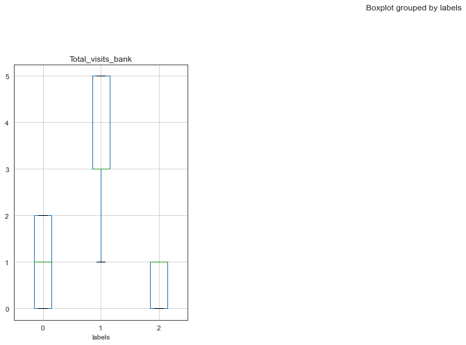

```python
df_labeled.boxplot(column=['Total_visits_bank'], by = 'labels',  layout=(2,4), figsize=(20, 15))
```

```
array([[<AxesSubplot:title={'center':'Total_visits_online'}, xlabel='labels'>,
        <AxesSubplot:>, <AxesSubplot:>, <AxesSubplot:>],
       [<AxesSubplot:>, <AxesSubplot:>, <AxesSubplot:>, <AxesSubplot:>]],
      dtype=object)
```

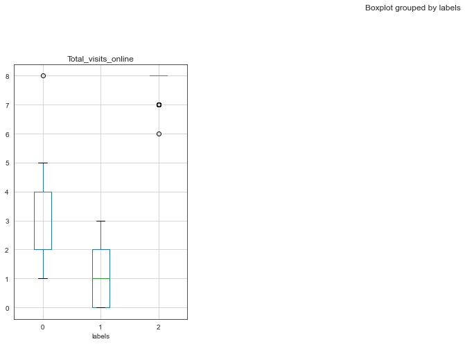

```python
df_labeled.boxplot(column=['Total_visits_online'], by = 'labels',  layout=(2,4), figsize=(20, 15))
```

```
array([[<AxesSubplot:title={'center':'Total_calls_made'}, xlabel='labels'>,
        <AxesSubplot:>, <AxesSubplot:>, <AxesSubplot:>],
       [<AxesSubplot:>, <AxesSubplot:>, <AxesSubplot:>, <AxesSubplot:>]],
      dtype=object)
```

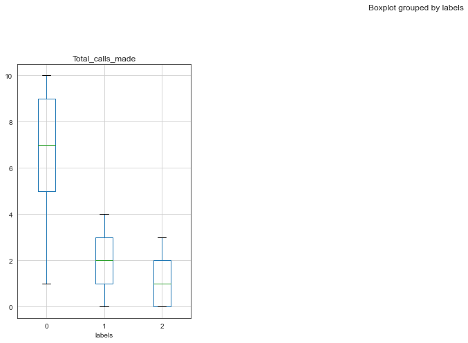

```python
df_labeled.boxplot(column=['Total_calls_made'], by = 'labels',  layout=(2,4), figsize=(20, 15))
```

# The box plots for the 3 clusters presents how they differ by cluster and where there is separation and overlap. There is good separation with the Total_Credit_Cards and Total_visits_online, and overlap with Total_visits_bank, Total_calls_made, and Avg_Credit_Limit.

```python
# Cluster comparsion of mean results.

results = pd.DataFrame()
results['Cluster'] = algo
results['Avg_Credit_Limit '] = cv_Credit_Limit
results['Total_Credit_Cards'] = cv_Credit_Cards
results['Total_visits_bank'] = cv_visits_bank
results['Total_visits_online'] = cv_visits_online
results['Total_calls_made'] = cv_calls_made
results['Cluster Count'] = cluster_count
results = results.set_index('Cluster')
results
```

| Cluster | Avg_Credit_Limit | Total_Credit_Cards | Total_visits_bank | Total_visits_online | Total_calls_made | Cluster Count |
| --- | --- | --- | --- | --- | --- | --- |
| Cluster1 | 12174.107143 | 2.410714 | 0.933036 | 3.544643 | 6.870536 | 224 |
| Cluster2 | 33782.383420 | 5.515544 | 3.489637 | 0.981865 | 2.000000 | 386 |
| Cluster3 | 102660.000000 | 8.740000 | 0.600000 | 7.820000 | 1.080000 | 50 |

# # Cluster comparsion of mean results shown tht Cluster 1 has 224 or 34% of the observations, Cluster 2 has 386 or 58%, and Cluster 3 has 50 or 8% of the observations . The data clearly show overlap for Total visits bank for Clusters 1 and 3. This was also shown in the box plot for Total visits bank.

# =============================================================

# 4. Execute hierarchical clustering (with different linkages) with the help of dendrogram and cophenetic coeff. Analyse clusters formed using boxplot (15 marks)

# =============================================================

```python
df_AttrAvg=df_filtered
```

```python
df_AttrAvgScaled = df_AttrAvg.apply(zscore)
df_AttrAvgScaled.head()
```

|  | Avg_Credit_Limit | Total_Credit_Cards | Total_visits_bank | Total_visits_online | Total_calls_made |
| --- | --- | --- | --- | --- | --- |
| 0 | 2.398942 | -1.249225 | -0.860451 | -0.627980 | -1.251537 |
| 1 | 0.643619 | -0.787585 | -1.473731 | 2.581387 | 1.891859 |
| 2 | 0.643619 | 1.058973 | -0.860451 | 0.288982 | 0.145528 |
| 3 | -0.058511 | 0.135694 | -0.860451 | -0.627980 | 0.145528 |
| 4 | 2.398942 | 0.597334 | -1.473731 | 2.581387 | -0.203739 |

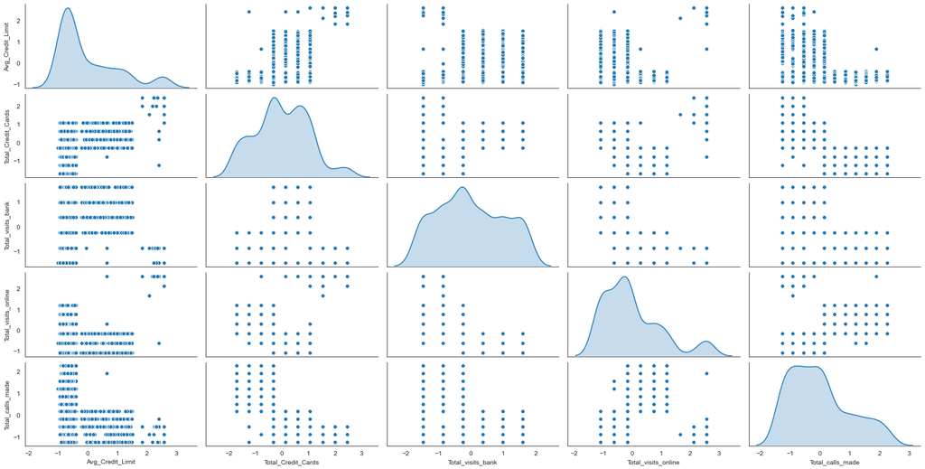

```python
sns.pairplot(df_AttrAvgScaled, height=2, aspect=2 , diag_kind='kde')
```

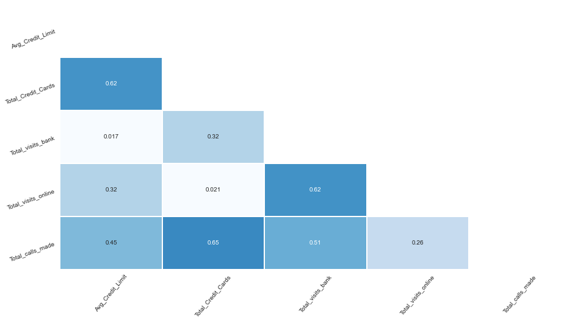

```python
np.tril(df.corr(), k = -1)
corr = abs(df_AttrAvgScaled.corr()) # correlation matrix
lower_triangle = np.tril(corr, k = -1)  # select only the lower triangle of the correlation matrix
mask = lower_triangle == 0  # to mask the upper triangle in the following heatmap

plt.figure(figsize = (15,8))  # setting the figure size
sns.set_style(style = 'white')  # Setting it to white so that we do not see the grid lines
sns.heatmap(lower_triangle, center=0.5, cmap= 'Blues', annot= True, xticklabels = corr.index, yticklabels = corr.columns,
            cbar= False, linewidths= 1, mask = mask)
plt.xticks(rotation = 50)   # Aesthetic purposes
plt.yticks(rotation = 20)   # Aesthetic purposes
plt.show()
```

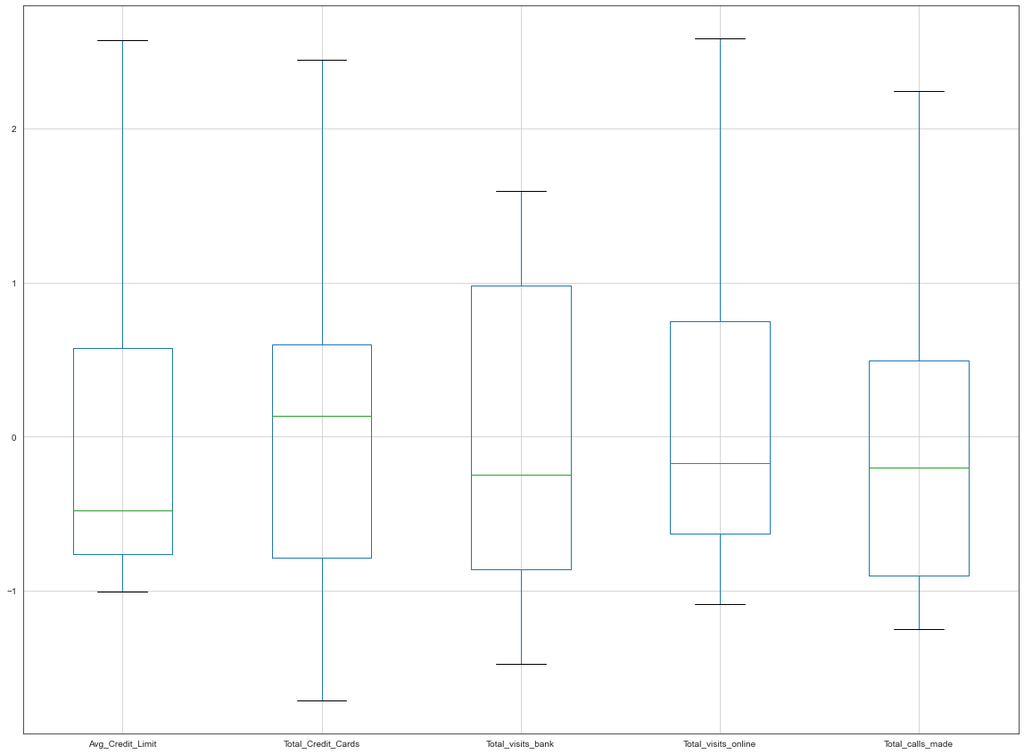

```python
df_AttrAvgScaled.boxplot(figsize=(20, 15))
```